# Homework 10

Shushi Meng

## Question 1

### (a) Simulation

I used R 4.5.1 and RLT 6.1.1, with data-generation seed 432. The five predictors have mean 0, variance 1, and pairwise correlation 0.3. I generated 200 test predictor vectors once. In each of 100 repetitions, I generated 200 new training observations with response X1 + X3 + X5 + independent N(0,1) noise. Every setting used the same training data within a repetition.

Each forest had 500 trees and sampled 200 observations with replacement per tree. Reinforcement was off. I varied node size over 1, 5, 10, 20, 30 with mtry=3, and mtry over 1–5 with node size 10. A node stopped splitting when it contained at most nmin observations. Other fitting settings stayed at their defaults. Forest seed was 10000 + repetition number, shared across settings within that repetition.

At each fixed test point, squared bias is (average prediction − f(x))². Variance is the average squared distance of the 100 predictions from their mean, using denominator 100. I then averaged each quantity over the 200 test points. These are finite-simulation estimates; the squared-bias estimate also contains some Monte Carlo error.

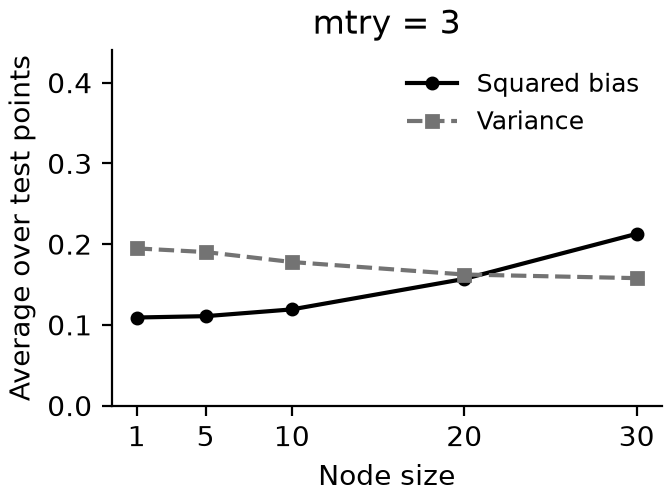

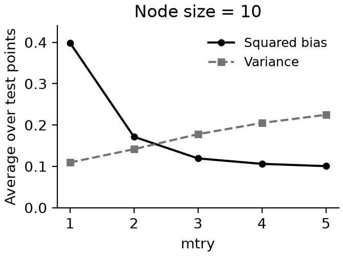

### (b) Bias and variance

At mtry=3, increasing node size from 1 to 30 reduced variance from 0.1947 to 0.1578, but increased squared bias from 0.1091 to 0.2127. Node size 30 stops splitting earlier, giving a coarser fit that misses more of the linear signal. The smallest estimated squared bias + variance was 0.2969 at node size 10, compared with 0.3705 at 30.

With node size 10, increasing mtry from 1 to 5 reduced squared bias from 0.3989 to 0.1004, but increased variance from 0.1093 to 0.2246. A larger mtry gives each split more chances to find a useful predictor, but also makes trees more similar, reducing the benefit of averaging. Here mtry=3 had the lowest sum, 0.2969; mtry=5 gave 0.3250. For predicting noisy Y rather than f(x), add the noise variance 1 to these sums.

If each tree sampled only 100 observations, I would tentatively favor smaller node sizes: a fixed threshold such as 30 becomes more restrictive relative to the smaller sample. Smaller nodes could recover some flexibility. However, smaller bootstrap samples also make trees noisier, so the best setting would need to be checked again; a shift is not guaranteed.

## Question 2

I kept digits 1, 6, and 7 from rows 1–1000 for training (327 observations: 116, 94, 117) and rows 1001–2000 for testing (317: 104, 106, 107). PCA centered the 784 training pixels without scaling. I used the first 20 PCs, explaining 77.13% of training pixel variance, and projected test pixels with the training means and loadings.

All fits used RLT classification, 1,000 trees, reinforcement off, and bootstrap samples of 327 observations per tree. Forest seed was 20432 for every setting. The grid and tie rule were fixed before test evaluation.

### (a) Default fit

RLT's defaults here were mtry=10 and nmin=5. The OOB misclassification rate was 14/327 = 0.0428 (4.28%).

### (b) OOB tuning and importance

The table gives OOB misclassification rates for all 24 settings.

| mtry | Node size 1 | 5 | 10 | 20 |
| --- | --- | --- | --- | --- |
| 1 | 0.0183 | 0.0183 | 0.0214 | 0.0245 |
| 3 | 0.0367 | 0.0367 | 0.0367 | 0.0398 |
| 5 | 0.0398 | 0.0398 | 0.0398 | 0.0398 |
| 10 | 0.0459 | 0.0428 | 0.0459 | 0.0459 |
| 15 | 0.0489 | 0.0489 | 0.0489 | 0.0520 |
| 20 | 0.0489 | 0.0489 | 0.0489 | 0.0489 |

The minimum was 6/327 = 0.0183, tied at mtry=1 with node sizes 1 and 5. My exact-tie rule preferred the larger node size, then the smaller mtry, so I selected **mtry=1, nmin=5**. Small mtry helped here, perhaps because useful information is spread across several PCs and less similar trees average better. The OOB minimum is a tuning result and can be optimistic after trying multiple settings. PCA also used all training rows, so this OOB check is conditional on that fitted representation.

The selected forest's native OOB permutation importance is below. Each value is the average increase in a tree's OOB misclassification rate after permuting that PC, in error-rate units.

| PC | Importance | PC | Importance | PC | Importance | PC | Importance |
| --- | --- | --- | --- | --- | --- | --- | --- |
| 1 | 0.0946 | 6 | 0.0300 | 11 | 0.0224 | 16 | 0.0172 |
| 2 | 0.1267 | 7 | 0.0231 | 12 | 0.0171 | 17 | 0.0117 |
| 3 | 0.0329 | 8 | 0.0116 | 13 | 0.0153 | 18 | 0.0187 |
| 4 | 0.0205 | 9 | 0.0141 | 14 | 0.0169 | 19 | 0.0129 |
| 5 | 0.0294 | 10 | 0.0194 | 15 | 0.0123 | 20 | 0.0147 |

PC2 and PC1 were most important (0.1267 and 0.0946); the remaining values were much smaller. The ordering need not follow PCA variance: explaining pixel variation is different from separating digits. These are predictive associations with PC combinations of pixels, not causal effects or individual-pixel importance.

### (c) Final test assessment

The selected forest made 6/317 mistakes: test error **0.0189 (1.89%)**. Observed classes are rows and predicted classes are columns:

| Observed / predicted | 1 | 6 | 7 |
| --- | --- | --- | --- |
| 1 | 101 | 0 | 3 |
| 6 | 0 | 106 | 0 |
| 7 | 0 | 3 | 104 |

There were three 1→7 errors and three 7→6 errors. This is one test split; each extra mistake would change the rate by about 0.32 percentage points. Test labels were used only after model selection.

## Question 3

### (a) How I would write the skill

I would write a short skill that states the analysis goal, the rules that prevent leakage, and the kind of report I want. A capable AI probably does not need a long explanation of how random forests work, but it still needs to know my data split, tuning rule, and reporting preferences. I would put the dataset, response, and any group or time restrictions in the invocation so the skill can be reused. For a less experienced AI, I would add a small example and a few checks for preprocessing and OOB predictions. I would keep instructions only when they prevent a likely mistake or express a choice I care about. My main preference is a short report with enough numbers to check the conclusion, without a long code listing or extra decoration.

### (b) Ten instructions, from basic to personal

1. Identify the response and whether the task is regression or classification. Check missing values, class counts, predictor types, and possible leakage before fitting.
2. Use the requested package and forest type. Record its version, random seeds, tree count, bootstrap size, node-size definition, and candidate-predictor setting.
3. Reserve the test set first and honor any group or time restrictions. Fit learned preprocessing on training data and apply it unchanged to test data.
4. Start with a default forest, then define a manageable mtry and node-size grid and a tie rule before examining tuning results. Use enough trees that the comparisons are reasonably stable.
5. Choose settings using training OOB error: misclassification rate for classification or mean squared error for regression. If substantial learned preprocessing is needed, use training cross-validation with preprocessing inside each fold instead.
6. Freeze the selected workflow before evaluating the test set. Report test error and, for classification, a confusion matrix with observed classes in rows. Do not retune from test results.
7. Calculate OOB permutation importance and explain what its units mean. Treat importance as predictive rather than causal, and mention that related predictors can share or mask importance.
8. Save runnable code and numerical results. Recalculate reported errors from saved predictions and check the sample sizes before writing the report.
9. Show the tuning results in one compact table and use a figure only when it makes a comparison easier. Give actual errors and denominators, and avoid treating tiny differences as clear wins.
10. Keep my report plain and concise: question-number headings, short paragraphs, readable black-and-white figures, and no decorative cover page. Explain the main finding and its limitation in ordinary language; leave long code and extra output in separate files.

Software reference: [RLT parameter and importance documentation](https://teazrq.github.io/RLT/reference/RLT.html).